# Intro to Epigenomics

Wade Boohar, updated by Joshua Lin and Jeanne Revilla

11/03/24

```r
# Change to your directory
 knitr::opts_knit$set(root.dir = normalizePath("/home1/marcelah/qbio_490_github/"))
```

#Package Download and Data-cleaning

```r
if (!require("sesameData", quietly = TRUE))
BiocManager::install("sesameData")
if (!require("sesame", quietly = TRUE))
BiocManager::install("sesame")
if (!require("limma", quietly = TRUE))
BiocManager::install("limma")
```

# Load in all necessary packages

```r
library(TCGAbiolinks)
library(sesame)
library(sesameData)
library(limma)
library(ggplot2)
```

# Query, Download, and Prepare the data.

```r
query <- GDCquery(project = "TCGA-BRCA",
                  data.category = "DNA Methylation",
                  data.type = "Methylation Beta Value",
                  platform = "Illumina Human Methylation 450",
                  data.format = "Dataframe")
```

```
## o GDCquery: Searching in GDC database
```

```
## Genome of reference: hg38
```

```
## oo Accessing GDC. This might take a while...
```

```
## ooo Project: TCGA-BRCA
```

```
## oo Filtering results
```

```
## ooo By platform
```

```
## The argument experimental_strategy does not match any of the results.
## Possible values:TXT
```

```
## ooo By data.type
```

```
## oo Checking data
```

```
## ooo Checking if there are duplicated cases
```

```
## ooo Checking if there are results for the query
```

```
## o Preparing output
```

```r
GDCdownload(query)
```

```
## Of the 895 files for download 895 already exist.
```

```
## All samples have been already downloaded
```

```r
methylation450 <- GDCprepare(query)
```

```
## oo Reading 895 files
```

```
## oo Merging 895 files
```

```
## Creating a SummarizedExperiment from DNA methylation input
```

```
## Accessing DNAm annotation from sesame package for: hg38 - HM450
```

```
## see ?sesameData and browseVignettes('sesameData') for documentation
```

```
## loading from cache
```

```
## require("GenomicRanges")
```

```
## Starting to add information to samples
```

```
##  => Add clinical information to samples
```

```
##  => Adding TCGA molecular information from marker papers
```

```
##  => Information will have prefix 'paper_'
```

```
## brca subtype information from:doi.org/10.1016/j.ccell.2018.03.014
```

The above data requires a LOT of memory. My recommendation: GDCdownload() and GDCprepare() in separate R sessions. R requires a lot of memory for both.

```r
methylation_clinical <- as.data.frame(methylation450@colData)
betas <- as.data.frame(methylation450@assays@data@listData) #takes a longer time
cpg_sites <- as.data.frame(methylation450@rowRanges@elementMetadata)

column_mask <- ifelse(colnames(methylation_clinical) %in% c('treatments', 'primary_site', 'disease_type','sites_of_involvement'), F, T)

methylation_clinical <- methylation_clinical[,column_mask]
write.csv(methylation_clinical, 'brca_methylation_clinical.csv')


site_mask <- !grepl('-', cpg_sites$gene) & !grepl(';', cpg_sites$gene) & !is.na(cpg_sites$gene) & complete.cases(betas)
betas <- betas[site_mask,]
cpg_sites <- cpg_sites[site_mask,]

write.csv(betas, 'brca_methylation_betas.csv') #takes a longer time
write.csv(cpg_sites, 'brca_cpg_sites.csv')
```

Use the code below if you are loading in your data (i.e. you downloaded the data and closed the session, but you are back to continue working)

```r
methylation_clinical <- read.csv('brca_methylation_clinical.csv', row.names = 1)
betas <- read.csv('brca_methylation_betas.csv', row.names=1)
cpg_sites <- read.csv('brca_cpg_sites.csv', row.names = 1)
```

# (1) Naive Differential Methylation

```r
#masking out NAs
metastasis_mask <- methylation_clinical$definition %in% c("Metastatic", "Primary solid Tumor")
methylation_clinical <- methylation_clinical[metastasis_mask, ]
betas_clean <- betas[, metastasis_mask]

#creating our variable of interest & deciding the base group
methylation_clinical$metastasis_category <- ifelse(methylation_clinical$definition== "Metastatic", "metastatic", "primary")

#define your comparison and base group
primary_mask <- methylation_clinical$metastasis_category == "primary"
methylation_clinical$metastatic <- !primary_mask #old is comparison, young is base

#fitting linear models using a "target value"
mval <- t(apply(betas_clean, 1, function(x) log2(x/(1-x))))
#mvalue is another statistic for methylation, centered at 0 and ranges from -1 to 1
#this step will take a few seconds to run

design <- model.matrix(~ metastatic, data = methylation_clinical)
fit <- lmFit(mval, design)
fit2 <- eBayes(fit)
```

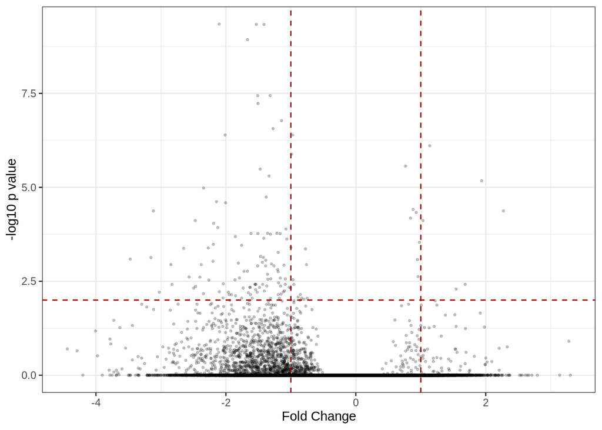

```r
# Extracting model into dataframe
dat <- data.frame(foldchange = fit[["coefficients"]][,2], logPvalue =  -log10(p.adjust(fit2[["p.value"]][,2],method='BY')), geneName = cpg_sites$gene)
dat$threshold <- as.factor(abs(dat$foldchange) < 1)

# Visualization
cols <- c("TRUE" = "grey", "FALSE" = "blue")
ggplot(data=dat, aes(x=foldchange, y = logPvalue)) +
  geom_point(alpha=.2, size=0.6) +
  scale_colour_manual(values = cols) +
  geom_vline(xintercept = 1, colour="#990000", linetype="dashed") +
  geom_vline(xintercept = - 1, colour="#990000", linetype="dashed") +
  geom_hline(yintercept = 2, colour = "#990000", linetype="dashed") +
  theme(legend.position="none") +
  xlab("Fold Change") +
  ylab("-log10 p value") +
  theme_bw() +
  theme(legend.position = "none")
```

```r
# Saving results to a .csv file
write.csv(dat, "methylation_results_metastasis.csv")
```

#What conclusions can you draw about diff. between metastatic and non-metastatic TCGA BRACA patients?

->from the volcano plot we can infer that there are several DNA sites that are significantly more or less (when looking at the negative and postitive folds) methylated when comparing metastatic to primary breast cancer patients. However, we cannot conclude whether these epigentic alteration directly result in or drive the progression of cancer. This is because the limitation in the observational comparison which only allows for correlation rather than causation analysis.This is because the plot does not consider other biological variable.

```r
de_results <- read.csv("../490_cluster/analysis_data/brca_deseq2_results.csv")

rna_clinical <- read.csv("../490_cluster/analysis_data/brca_rna_clinical_data.csv", row.names = 1)
rna_genes <- read.csv("../490_cluster/analysis_data/brca_rna_gene_data.csv")
rna_counts <- read.csv("../490_cluster/analysis_data/brca_rna_count_data.csv", row.names = 1)
```

```r
de_results$gene_id_clean <- sub("\\\\..*", "", de_results$X)
rna_genes$gene_id_clean <- sub("\\\\..*", "", rna_genes$gene_id)


de_results_mapped <- merge(de_results, rna_genes, by.x = "gene_id_clean", by.y = "gene_id_clean")
downregulated <- de_results_mapped[(de_results_mapped$log2FoldChange < -1 & !is.na(de_results_mapped$padj) & de_results_mapped$padj < 0.05), 'gene_name']
hypermethylated <- dat[dat$foldchange > 1.5, 'geneName'] #What cutoff should you use -> cutoff of 1.5 because it successfully filters for highly hypermethylated genes.


interest_genes <- intersect(downregulated, hypermethylated)
print(interest_genes)
```

```
##  [1] "CFTR"       "MEOX1"      "NFIX"       "CHI3L2"     "HDAC4"
##  [6] "NTN4"       "FGFR1"      "CDH17"      "LTBP4"      "ZFHX4"
## [11] "CCDC80"     "SORBS1"     "PTPRS"      "CPVL"       "SLC2A9"
## [16] "ZBTB16"     "NEDD9"      "WLS"        "AHNAK"      "KIF25"
## [21] "HSPA12B"    "ZBED3"      "CLDN10"     "TRIM29"     "FBLN5"
## [26] "SLC2A5"     "MYOM3"      "IQGAP2"     "TENM2"      "SYT8"
## [31] "CCL28"      "UBASH3B"    "SKI"        "DUSP2"      "CACHD1"
## [36] "KALRN"      "KLHL21"     "BRINP3"     "ADAMTS9"    "NAV2"
## [41] "TNXB"       "PIK3CD"     "CSPG4"      "GREM2"      "PCBP3"
## [46] "WDR86"      "ARID5A"     "DLGAP2"     "GRK5"       "GPR20"
## [51] "C2CD4B"     "SERPINB5"   "LINC01359"  "LINC01579"  "AF067845.1"
```

```r
interest_genes <- c("FGFR1")
GENE <- "FGFR1"

gene_counts_mask <- rna_genes$gene_name == GENE
gene_betas_mask <- cpg_sites$gene == GENE

#What are we doing here? -> creating column masks to separate your patients and samples by disease stage (Metastatic vs. Non)
rna_metastatic_mask <- rna_clinical$definition == "Metastatic"
rna_primary_mask <- rna_clinical$definition == "Primary solid Tumor"

meth_metastatic_mask <- methylation_clinical$metastasis_category == "metastatic"
meth_primary_mask <- methylation_clinical$metastasis_category == "primary"

#What are we doing here? -> extracting the final data from DNAH10, turning RNA data into numerical imputs (1 dimensional) and methylation into matrices (2 dimensional) inputs
rna_metastatic <- as.numeric(rna_counts[gene_counts_mask, rna_metastatic_mask])
rna_primary <- as.numeric(rna_counts[gene_counts_mask, rna_primary_mask])


methylation_metastatic <- betas_clean[gene_betas_mask, meth_metastatic_mask, drop = FALSE]
methylation_primary <- betas_clean[gene_betas_mask, meth_primary_mask, drop = FALSE]
```

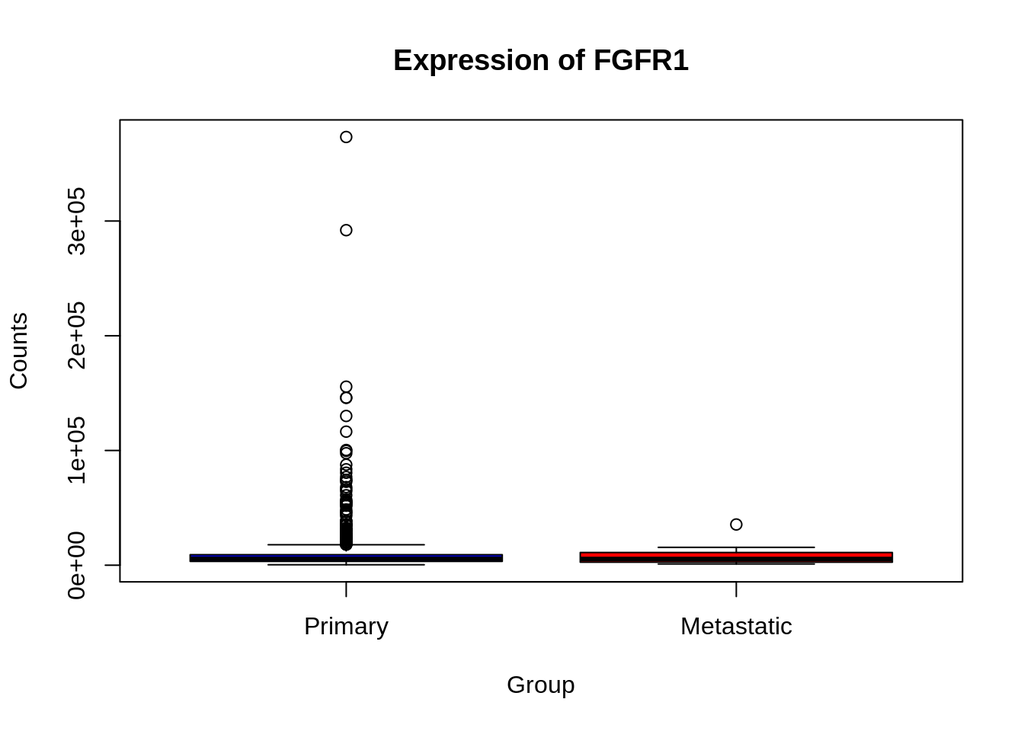

```r
boxplot(rna_primary, rna_metastatic,
        xlab = 'Group',
        ylab = 'Counts',
        names = c('Primary', 'Metastatic'),
        col = c("blue", "red"),
        main = paste("Expression of", GENE))
```

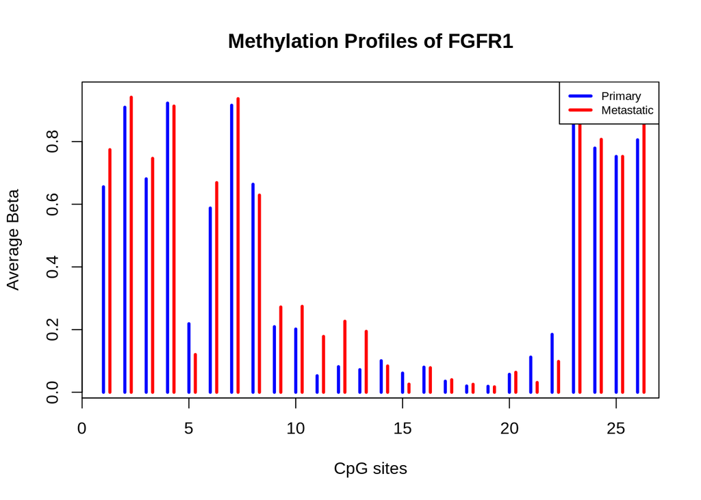

```r
plot(1:nrow(methylation_primary), apply(methylation_primary, 1, mean, na.rm = TRUE),
     col = 'blue', type = 'h', lwd = 3,
     ylab = 'Average Beta', xlab = 'CpG sites',
     main = paste("Methylation Profiles of", GENE))

lines(1.3:(nrow(methylation_metastatic) + 0.3), apply(methylation_metastatic, 1, mean, na.rm = TRUE),
      col = 'red', type = 'h', lwd = 3)

legend("topright",
       legend = c("Primary", "Metastatic"),
       col = c("blue", "red"),
       lwd = 3,
       cex = 0.7)
```

#Direct comparison of methylation status to transcriptional activity across non-metastatic vs. metastatic patients in 1 gene of interest (Box plot & bar plot):